# Advanced Visualizations Lecture 01

## Advanced Graphics and Data Visualization in R

## Lecture 01: “R”-efresher on R and best practices live HTML

## 0.1.0 An overview of Advanced Graphics and Data Visualization in R

**“Advanced Graphics and Data Visualization in R”** is brought to you by the Centre for the Analysis of Genome Evolution & Function’s (CAGEF) bioinformatics training initiative. CSB1021 was developed to enhance the skills of students with basic backgrounds in R by focusing on available philosophies, methods, and packages for plotting scientific data. Many of the datasets and examples used in this course will be drawn from real-world datasets and the techniques learned herein aim to be broadly applicable to multiple fields.

This lesson is the first in a 6-part series. The aim for the end of this series is for students to recognize how to import, format, and display data based on their intended message and audience. The format and style of these visualizations will help to identify and convey the key message(s) from their experimental data.

The structure of the class is a **code-along style** in R markdown notebooks. At the start of each lecture, skeleton versions of the lecture will be provided for use on the [University of Toronto datatools Hub](https://datatools.utoronto.ca) so students can program along with the instructor.

## 0.2.0 Lecture objectives

This week will be your crash-course on R markdown notebooks and R to refresh on packages and principles that will be relevant throughout our course. In our lectures and your assignments we will be working with some uncurated data to simulate the full experience of working with data from start to finish. It’s important that we are all familiar with, and understand the majority of the tidy data methods that we’ll be using in class so that we can focus on the new material as it appears. We’ll use some standard packages and practices to finesse our data before visualizing it, so let’s R-efresh ourselves.

At the end of this lecture we will have covered the following topics:

1. Working with R markdown notebooks and best coding practices.
2. R data types, objects and working with them.
3. Long-format and tidy data principles using the `tidyverse` package.
4. Basic control flow and plotting.

## 0.3.0 A legend for text format in R markdown

`grey background` - a package, function, code, command or directory. Backticks are also use for in-line code.  
*italics* - an important term or concept or an individual file or folder  
**bold** - heading or a term that is being defined  
blue text - named or unnamed hyperlink

`...` - Within each coding cell this will indicate an area of code that students will need to complete for the code cell to run correctly.

**Blue box:** A key concept that is being introduced

**Yellow box:** Risk or caution

**Green boxes:** Recommended reads and resources to learn R

**Red boxes:** A comprehension question which may or may not involve a coding cell. You usually find these at the end of a section.

## 0.4.0 Lecture and data files used in this course

### 0.4.1 Weekly Lecture and skeleton files

Each week, new lesson files will appear within your RStudio folders. We are pulling from a GitHub repository using this [Repository git-pull link](https://r.datatools.utoronto.ca/hub/user-redirect/git-pull?repo=https%3A%2F%2Fgithub.com%2Fuoft-csb-datasci%2F2026-03-Adv_Graphics_R&urlpath=rstudio%2F&branch=main). Simply click on the link and it will take you to the [University of Toronto datatools Hub](https://datatools.utoronto.ca). You will need to use your UTORid credentials to complete the login process. From there you will find each week’s lecture files in the directory `/2026-03-Adv_Graphics_R/Lecture_XX`. You will find a partially coded `skeleton.Rmd` file as well as all the data files necessary to run the week’s lecture.

Alternatively, you can download the R-Markdown Notebook (`.Rmd`) and data files from the RStudio server to your personal computer if you would like to run independently of the Toronto tools.

### 0.4.2 Live-coding HTML page

A live lecture version will be available at [camok.github.io](https://uoft-csb-datasci.github.io/2026-03.Adv_Graphics_R/index.html) that will update as the lecture progresses. Be sure to refresh to take a look if you get lost!

### 0.4.3 Post-lecture PDFs

At the end of each lecture there will be a completed version of the lecture code released as an HTML file under the Modules section of Quercus.

### 0.4.4 Data used in this lesson

Today’s datasets will focus on using a [Federal Respiratory Virus Detections dataset](https://www.canada.ca/en/public-health/services/surveillance/respiratory-virus-detections-canada.html). This data was used to compile a [weekly FluWatch report](https://www.canada.ca/en/public-health/services/diseases/flu-influenza/influenza-surveillance/weekly-influenza-reports.html). The data we’ll use today is a compilation of the 2022-2023 and 2023-2024 datasets. This will be an interesting dataset to look at since it contains datapoints across time regarding the testing and positive results for multiple respiratory viruses.

### 0.4.4.1 Dataset 1: 2022-24_surveillanceDataset.csv

This dataset contains the amalgamated observations of virus testing reports for multiple reporting laboratories across Canada during the respiratory seasons of 2022-2023 and 2023-2024. Seasons tend to begin in the 35th week of the year and end on the 34th week (or earlier) of the next calendar year.

## 0.5.0 Packages used in this lesson

`tidyverse` which has a number of packages including `dplyr`, `tidyr`, `stringr`, `forcats` and `ggplot2`

`viridis` helps to create color-blind palettes for our data visualizations

`lubridate` and `zoo` are helper packages used for working with date formats in R

Let’s run our first code cell!

```r
# Packages to help tidy our data
library(tidyverse)
library(magrittr)
```

# 1.0.0 Coding in R Markdown Notebooks

Work with your R markdown notebook on the University of Toronto datatools hub will all be contained within a new browser tab with the address bar showing something similar to

`https://r.datatools.utoronto.ca/user/calvin.mok@utoronto.ca/rstudio/`

All of this is running remotely on a University of Toronto server rather than your own machine.

You’ll see a directory structure from your home folder:

ie `/home/rstudio/2026-03-Adv_Graphics_R/` and a folder to `Lecture_01_R_Introduction` within. Clicking on that, you’ll find `Lecture_01.R-efresher.skeleton.Rmd` which is the notebook we will use for today’s code-along lecture.

## 1.1.0 Why is this class using R Markdown Notebooks?

We’ve implemented the class this way to reduce the burden of having to install various programs. While installation can be a *little* tricky, it’s really not that bad. For this course, however, you don’t need to go through all of that just to improve on your data visualization skills.

R markdown notebooks also give us the option of inserting “markdown” text much like what you’re reading at this very *exact* moment. So we can intersperse ideas and information between our learning code blocks.

There is, however an appendix section at the end of this lecture detailing how to install the R-kernel itself and the integrated development environment (IDE) called RStudio.

## 1.2.0 Packages contain useful functions that we’ll use often

So… what are in these packages? A **package** can be a collection of - functions - data objects - compiled code - functions that *override* base functions in R

**Functions** are the basic workhorses of R; they are the tools we use to analyze our data. Each function can be thought of as a unit that has a specific task. A function takes an input, evaluates it using an expression (e.g. a calculation, plot, merge, etc.), and returns an output (a single value, multiple values, a graphic, etc.).

In this course we will frequently rely on a package called the `tidyverse` which is also composed of a series of other packages we can use to reformat our data like `readr`, `dplyr`, `tidyr` and `stringr`.

## 1.3.0 R markdown notebooks run the programming language R

Behind the scenes of each markdown notebook the R kernel is running. As we move from code cell to new code cell, all of the variables or objects we have created are stored within memory. We can refer to these as we run the code and move forward but if you overwrite or change them by mistake, you may to have rerun multiple cell blocks!

There are some options in the “Code” menu that can alleviate these problems such as “Run Region > Run All Chunks Above”. If you think you’ve made a big error by overwriting a key object, you can use that option to “re-initialize” all of your previous code!

Unfortunately, the run order of your code is not tracked. When a code cell is still actively running you will see in the top-right corner of the `Console` window (lower pane) denoted as a `STOP` sign icon. Clicking on this will interrupt the kernel and stop code execition, although depending on the complexity of the code it may take a moment.

**Remember these friendly keys/shortcuts:**

- `Arrow` keys to navigate up and down (and within a cell)
- `Ctrl`+`Shift`+`Enter` to run a cell (both code and markdown)
- `Ctrl`+`Enter` to run a single line of code within a code cell
- `Alt`+`Ctrl`+`Enter` to run the next cell
- `Ctrl`+`Shift`+`C` to quickly comment and uncomment single or multiple lines of code
- `Tab` can be used while coding to autocomplete variable, function and file names, and even look at a list of possible parameters for functions.
- `Ctrl`+`Alt`+`I` to insert a new coding cell

### 1.3.3 Why would you want to use a Markdown Notebook?

Depending on your needs, you may find yourself doing the following:

- Analysing data for your project using available packages
- Re-analysing data for your project
- Analysing multiple datasets for your project
- Collaborating on data and analyses for your project
- **Explaining** your data and analyses to a supervisor or collaborator!

Markdown allows you to alternate between “markdown” notes and “code” that can be run or re-run on the fly.

Each data run and its results can be saved individually as a new notebook to compare data and small changes to analyses!

### 1.3.4 What is markdown language?

Markdown is a markup language that lets you write HTML and Java Script code in combination with other languages. This allows you to make html, pdf, and text documents that are combinations of text and code, enhancing reproducibility, a key aspect in scientific work. Having everything in a single place also boosts productivity during results interpretation - no need to go back and forth between tabs, pages, and documents. They can all be integrated in a single document, allowing for a more fluid narrative of the story that you are communicating to your audience (less distractions for you!). For example, the lines of code below and the text you are reading right now were created in R’s Markdown language. (Do not worry about the R code just yet. We will get there sooner than you think).

$$Y_i = \beta_0 + \beta_1 x_i + \varepsilon_i, i=1, \dots,N$$

See? Just like that! Here is an example of a table made in Markdown, showing some of the most popular R libraries for data science:

| Library | Use |
| --- | --- |
| tidyverse | Simplified tabular-data processing functions |
| ggplot2 | Data visualization package typically included in the tidyverse |
| shiny | Used to create interactive R-based web pages and interfaces |
| car | Popular statistical analysis with Type II and III ANOVA tables |

These are just a few examples of what you can do with Jupyter and Markdown. To find out more on how to get the best of Markdown, head on over to the [R Markdown cookbook] (https://bookdown.org/yihui/rmarkdown-cookbook/).

Once you are finished writing your code and interpreting those results in a markdown notebook, you can render the notebook into pdf, html, and many other formats. There are several ways to achieve this. The easiest option is to go to **File > Knit Document**. Afterwards there should be an option to view in browser at which point you can save as an HTML or print it to PDF.

## 1.4.0 Following best practices for coding will make life easier

Let’s discuss some important behaviours before we begin coding:

- Code annotation (commenting)
- Variable naming conventions
- Best practices

### 1.4.1 Annotate your code with the `#` symbol

**Why bother?**

- “Can you rerun this analysis and but change X parameter?” - *Anonymous PI*
- “Can you make this plot, but with dashed lines, a different axis, with error bars?” - *Anonymous labmate*
- “Can I borrow your code?” - *Anonymous collaborator or officemate or PI*
- “Why is that object being sent to that function? What is it returning?” - *You, Me, and anyone reading your code*

**Your worst collaborator is potentially you in 6 days or 6 months. Do you remember what you had for breakfast last Tuesday?**

[figure not shown]

Credit: https://www.testbytes.net/blog/programming-memes/

You can annotate your code for selfish reasons, or altruistic reasons, but annotate your code.

**How do I start?**

- It is, in general, part of best coding practices to keep things tidy and organized.
- A hash-tag `#` will comment your text. Inside a code cell in an R notebook or anywhere in an R script, all text *after* a hashtag will be ignored by R and by many other programming languages. It’s very useful to add comments about changes in your code, as well as detailed explanations about your scripts.
- Put a description of what you are doing near your code at every process, decision point, or non-default argument in a function. For example, why you selected `k=6` for an analysis, or the Spearman over Pearson option for your correlation matrix, or quantile over median normalization, or why you made the decision to filter out certain samples.
- Break your code into sections to make it readable. Scripts are just a series of steps and major steps should be titled/outlined with your reasoning - much like when presenting your research.
- Give your objects informative object names **that are not the same as function names**.

**Comments may/should appear in three places:**

- At the beginning of your code: What’s the objective of your script?
- Above every function you create: Why did you have to write your own function versus those that are already available in package x?
- In-line or in-between lines of code: Why did you write that piece of code? What does it do? Why did you change a function’s defaults?

```
# Example commenting section
# At the beginning of the script, describing the purpose of your script and what you are trying to solve

bedmasAnswer <- 5 + 4 * 6 - 0 #In line: Describing a part of your code that is not obvious what it is for.

#---------- Section dividers helps organize code structure ----------#
## Feel free to add extra hash tags to visually separate or emphasize comments
```

**Maintaining well-documented code is also good for mental health!**

### 1.4.2 Naming conventions for files, objects, and functions in R

- Cannot start with a number
- Cannot contain spaces or special characters in the name
- Avoid naming your variables using names already used by R (for, next, while, etc.).
- Consider appending the object type to your variable name (data frame = df, list = list, etc.)

**Stylistically, you have the following options:**

- All lower case: e.g. **myfirstobject**
- Period separated: e.g. **my.first.object**
- Underscore separated: e.g. **my_first_object**
- camelCase1: e.g. **myFirstObject**
- CamelCase2: e.g. **MyFirstObject** (Usually reserved for *Class* names)

The most important aspects of naming conventions are being concise and consistent! Throughout this course you’ll see a hybrid system that uses the **underscore** to separate words but a **period** right before denoting the object type ie `this_data.object`.

### 1.4.3 Best Practices for Writing Scripts

- Start each script with a description of what it does.
- Then load all required packages.
- Consider what working directory you are in when sourcing a script.
- Use comments to mark off sections of code.
- Put function definitions at the top of your file, or in a separate file if there are many.
- Name and style code consistently.
- Break code into small, discrete pieces.
  - This is more easily accomplished when working with different code cells in Jupyter Notebook.
- Factor out common operations rather than repeating them.
- Keep all of the source files for a project in one directory and use relative paths to access them.
  - Using relative paths close to or inside your script’s directory makes it easier to package or move around your scripts too.
- Keep track of the memory used by your program.
- Always start with a clean environment instead of saving the workspace.
- Keep track of session information in your project folder.
- Have someone else review your code.
- Use version control.

For more information on best coding practices, please visit [swcarpentry](https://swcarpentry.github.io/r-novice-inflammation/06-best-practices-R/)

## 1.5.0 Trouble-shooting basics

[figure not shown]

We all run into problems. We’ll see a lot of mistakes happen in class too! That’s OK if we can learn from our errors and quickly (or eventually) recover.

### 1.5.1 Determine the location and type of error

Usually when R generates an error it will produce some information about what has happened. This usually includes an error message detailing the *kind of error* it encountered or an error message generated by the function. It can also include a line where the error was encountered, or the name of the last function that was called before the error was encountered.

### 1.5.2 Common errors

- *file does not exist*: Use `getwd()` to check where you are working, type`list.files()` or the `Files` pane to check that your file exists there, and `setwd()` to change your directory if necessary. Preferably, work inside an *R project* with all project-related files in that same folder. Your working directory will be set automatically when you open the project (this can be done by using `File -> New File -> R Notebook` and following prompts).
- *typos*: R is case sensitive so always check that you’ve spelled everything right. Get used to using the *tab autocomplete* feature when possible. This can reduce typos and increase your overall programming speed.
- *open quotes, parentheses, brackets*:
  - **R Markdown Notebooks** highlight the current cursor-denoted bracket set in $\color{grey}{\text{grey}}$. If the bracket is unmatched on either side, a small red $\color{red}{\text{X}}$ icon will appear on the left-hand side of the code cell, beside the line numbers.
- *data type*: Use commands like `typeof()` and `class()` to check what type of data you have. Use `str()` to peak at your data structures if you’re making assumptions about it.
- *unexpected answers*: To access the *help menu*, type `help("function")`, `?function` (using the name of the function that you want to check), or `help(package = "package_name")`.
  - **In RStudio**: the result will appear in a side-panel on the bottom right of the development environment.
- *function not found*: Make sure the package name is properly spelled, installed, AND loaded. Libraries can be loaded to the environment using the function `library("package_name")`. If you only need one function from a package, or need to specify to what package a function belongs because there are functions with the same name that belong to different packages, you can use a double colon, i.e. `package_name::function_name`.
- *the R bomb!!*: The `session aborted` can happen for a variety of reasons, like not having enough computational power to perform a task or also because of a system-wide failure.
  - **RStudio**: restart the Kernel from the menu `Session -> Restart R`. You will need to rerun your previous cells!
- **cheatsheets**: Meet your new best friends: [cheatsheets](https://rstudio.com/resources/cheatsheets/)!

[figure not shown]

### 1.5.3 Finding answers online

- 99% of the time, someone has already asked your question
- Google, Stack overflow, R Bloggers, SEQanswers, Quora, ResearchGate, RSeek, twitter, even reddit
- Including the program, version, error, package and function helps, so be specific. Sometimes it is useful to include your operating system and version (Windows 10, Ubuntu 18, Mac OS 10, etc.).
- You may run into assignment questions where the tools I’ve provided in lecture are not enough to reproduce the example output *exactly* as provided. If you wish to go that extra mile you may need to look for answers elsewhere by consulting references from the class or searching for it yourself. *The truth is out there!*

### 1.5.3.1 Asking a question in an online forum

- Summarize your question in the title (be concise and objective!).
- Introduce your question, how you ran into the problem, **and how you tried to solve it yourself**. If you haven’t done the bolded thing, do the bolded thing.
- Show enough of your code and data for others to try to reproduce the problem/error. This is often referred to as a reproducible example or reprex.
- Add tags that match your problem.
- Respond to the feedback and vote for the answered that you picked. People put in their free time to answer and help you.
- Take a look at [StackOverflow’s tips on how to ask questions](https://stackoverflow.com/help/how-to-ask), as well as [CRAN’s](https://www.r-project.org/posting-guide.html)

**Remember**: Everyone looks for help online **ALL THE TIME**. It is very common. Also, with programming there are multiple ways to come up with an answer, even different packages that let you do the same thing in different ways. You will work on refining these aspects of your code as you go along in this course and in your coding career.

Last but not least, to make life easier: Under the `Help` pane, there is a list of cheatsheets related to RStudio, the tidyverse and other useful packages.

[figure not shown]

# 2.0.0 Foundations of R

There are many tips and tricks to remember about R but here we’ll quickly recall some fundamental knowledge that could be relevant in later lectures.

## 2.1.0 Assigning variables

If we want to hold on to a number, calculation, or object we need to *assign* it to a named variable. R has multiple methods for assigning a value to a variable and an order of precedence!

`->` and `->>` **Rightward assignment**: we won’t really be using this in our course.

`<-` and `<<-` **Leftward assignment**: assignment used by most ‘authentic’ R programmers but really just a historical keyboard throwback.

`=` **Leftward assignment**: commonly used token for assignment in many other programming languages but holds dual meaning!

### Notes

- In R, the assignment of a variable *does not* produce any standard output.
- R processes at each new line unless you use a semicolon (;) to separate commands. This applies to assignment as well. One exception being when your function calls are spaced across lines and contained within the `()`.
- R calculates the right side of the assignment first the result is then applied to the left.
  - This is a common paradigm in programming that simplifies variable behaviours for counting and tracking results as they build up over time. This also allows us to increment variables or manipulate objects to update them!

## 2.2.0 Data types are the basic building blocks of R

Data types are used to classify the basic spectrum of values that are used in R. Here’s a table describing *some* of the common data types we’ll encounter.

| Data type | Description | Example |
| --- | --- | --- |
| character | Can be single or multiple characters (strings) of letters and symbols. Assigned using double `'` or `"` | a#c&E |
| integer | Whole number values, either positive or negative | 1 |
| double | Any number that is not an integer | 7.5 |
| logical | Also known as a boolean, representing the state of a conditional (question) | TRUE or FALSE |
| factor | Used as a way to make categorical values. Often used as a finite set of values that appear to be string-based in nature except they can be given a user-specified order. | Yes/No or Low/Medium/High |
| NA | Represents the value of “Not Available” usually seen when imported data has missing values | NA |

### 2.2.1 Data structures hold single or multiple values

The job of data structures is to “host” the different data types. There are five basic types of data structures that we’ll use in R:

| Data structure | Dimensions | Restrictions |
| --- | --- | --- |
| vector | 1D | Holds a single data type |
| matrix | 2D | Holds a single data type |
| array | nD | Holds a single data type |
| data frame | 2D | Holds multiple data types with some restrictions |
| list | 1D (technically) | Holds multiple data types AND structures |

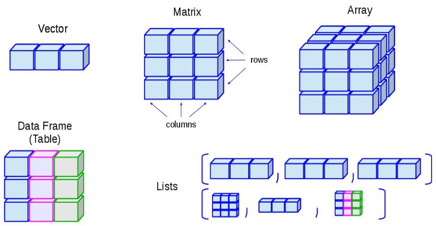

Sometimes it is helpful to imagine Data Structures as real-world objects to understand how they are shaped and related to each other.

### 2.2.2 Vectors are like a queue of a single data type

- Also known as atomic vectors, each element within a vector must be of the same data type: **logical, integer, double, character**, complex, or raw.
- For each vector there are two key properties that can be queried with `typeof()` and `length()`.
- There is a numerical order to a vector, much like a queue AND you can access each element (piece of data) individually or in groups. Elements are ordered from `1` to `length(your_vector)` and can be accessed with an indexing operator `[]`
- Elements of a vector may be **named**, to facilitate subsetting by character vectors.
- Elements of a vector may be subset by a logical vector.

```r
# Build a character vector
char.vector <- c("Canada", "Maple Syrup", "Hockey")
char.vector
```

```
## [1] "Canada"      "Maple Syrup" "Hockey"
```

```r
# subset by a single value
char.vector[1]
```

```
## [1] "Canada"
```

```r
# subset by multiple values
char.vector[2:3]
```

```
## [1] "Maple Syrup" "Hockey"
```

```r
# subset by removing values (cannot be mixed with positive values)
char.vector[c(-1, -3)]
```

```
## [1] "Maple Syrup"
```

```r
# subset with repeating multiple values
char.vector[c(1, 2, 3, 3, 2, 1)]
```

```
## [1] "Canada"      "Maple Syrup" "Hockey"      "Hockey"      "Maple Syrup"
## [6] "Canada"
```

```r
# Build a named character vector by including variable names
character.vector <- c(a = "Canada", b = "Maple Syrup", c = "Hockey")
character.vector
```

```
##             a             b             c
##      "Canada" "Maple Syrup"      "Hockey"
```

```r
# subset by element name
character.vector[c("a", "c")]
```

```
##        a        c
## "Canada" "Hockey"
```

```r
# subset by an explicit vector of logicals
character.vector[c(FALSE, TRUE, TRUE)]
```

```
##             b             c
## "Maple Syrup"      "Hockey"
```

```r
# Or subset by an implicit vector of logicals
character.vector[character.vector != "Canada"]
```

```
##             b             c
## "Maple Syrup"      "Hockey"
```

### 2.2.2.1 Coercion changes data from one type to another (where applicable)

R will implicitly force (*coerce*) your vector to be of one data type. In this case, the type that is most inclusive is a character vector. When we explicitly coerce a change from one data type to the next, it is known as *casting*. You can cast between certain data types and also object types.

- Type-casting examples: `as.logical()`, `as.integer()`, `as.double()`, `as.numeric()`, `as.character()`, and `as.factor()`
- Structure casting examples: `as.data.frame()`, `as.list()`, and `as.matrix()`

Importantly, when coercing, the R kernel converts from more specific to general types usually in this order:

logical $\rightarrow$ integer $\rightarrow$ numeric $\rightarrow$ complex $\rightarrow$ character $\rightarrow$ list.

```r
# Make a logical vector and display its structure
logical.vector <- c(TRUE, FALSE, TRUE, FALSE, FALSE)
str(logical.vector)
```

```
##  logi [1:5] TRUE FALSE TRUE FALSE FALSE
```

```r
# Make a numeric vector and display its structure
numeric.vector <- c(-1:10)
str(numeric.vector)
```

```
##  int [1:12] -1 0 1 2 3 4 5 6 7 8 ...
```

```r
# Make a mixed vector and display its structure. Take a note of its typing afterwards
mixed.vector <- c(FALSE, TRUE, 1, 2, "three", 4, 5, "six")
str(mixed.vector)
```

```
##  chr [1:8] "FALSE" "TRUE" "1" "2" "three" "4" "5" "six"
```

```r
# Attempt to coerce our vectors
# logical to numeric
as.numeric(logical.vector)
```

```
## [1] 1 0 1 0 0
```

```r
# numeric to logical
as.logical(numeric.vector)
```

```
##  [1]  TRUE FALSE  TRUE  TRUE  TRUE  TRUE  TRUE  TRUE  TRUE  TRUE  TRUE  TRUE
```

```r
# numeric to character
as.character(numeric.vector)
```

```
##  [1] "-1" "0"  "1"  "2"  "3"  "4"  "5"  "6"  "7"  "8"  "9"  "10"
```

```r
# mixed to a numeric. Note what happens when elements cannot be converted
as.numeric(mixed.vector)
```

```
## [1] NA NA  1  2 NA  4  5 NA
```

### 2.2.3 Data Frames hold tabular data

### 2.2.3.1 Object classes

Now that we have had the opportunity to create a few different vector objects, let’s talk about what an object *class* is. An object class can be thought of as a structure with attributes that will behave a certain way when passed to a function. Because of this

- data frames, lists and matrices have their own classes
- vectors inherit from their data type (**e.g.** vectors of characters behave like characters)

Some R package developers have created their own object classes. For example, many of the functions in the `tidyverse` generate `tibble` objects. They behave in most ways like a `data.frame` but have a more refined print structure, making it easier to see information such as column types when viewing them quickly. In general, from a trouble-shooting standpoint, it is good to be aware that your data *may* need to be formatted to fit a certain class of object when using different packages.

After we are done tidying most of our datasets, they will be in tibble objects, but all of the basic data frame functions apply to these as well.

### 2.2.3.2 Data frames are groups of vectors aligned as columns

While matrices are 2-dimensional structures limited to a single specific type of data within each instance, data frames treat each column of the structure like a vector. The data frame, however, can have multiple data types mixed across each *different* column. Data frame rules to remember are:

1. Within a column, all members must be of the same data type (ie character, numeric, Factor, etc.)
2. All columns must have the same number of rows (hence the matrix shape)

Data frames allows us to generate tables of mixed information much like an Excel spreadsheet.

```r
# Generate a data frame with different variable/column types
mixed.df <- data.frame(Canadiana = character.vector,
                       values = numeric.vector[2:4],
                       manmade = logical.vector[1:3])

# View the data frame
mixed.df
```

```
##     Canadiana values manmade
## a      Canada      0    TRUE
## b Maple Syrup      1   FALSE
## c      Hockey      2    TRUE
```

```r
# Check the structure of the data frame
str(mixed.df)
```

```
## 'data.frame':    3 obs. of  3 variables:
##  $ Canadiana: chr  "Canada" "Maple Syrup" "Hockey"
##  $ values   : int  0 1 2
##  $ manmade  : logi  TRUE FALSE TRUE
```

### 2.2.3.3 Some useful data frame commands (for now)

- `nrow(data_frame)` retrieves the number of rows in a data frame.
- `ncol(data_frame)` retrieves the number of columns in a data frame.
- `data_frame$column_name` accesses a specific column by its name.
- `data_frame[x,y]` accesses a specific element located at row x, column y
- `rownames(data_frame)` retrieves or assigns row names to your data frame
- `colnames(data_frame)` retrieves or assigns columns names to your data frame

There are many more ways to access and manipulate data frames that we’ll explore further down the road. Let’s review some basic data frame code.

```r
# query the dimensions of the data frame
dim(mixed.df)
```

```
## [1] 3 3
```

```r
nrow(mixed.df)
```

```
## [1] 3
```

```r
ncol(mixed.df)
```

```
## [1] 3
```

```r
# retrieve row and column names
rownames(mixed.df)
```

```
## [1] "a" "b" "c"
```

```r
colnames(mixed.df)
```

```
## [1] "Canadiana" "values"    "manmade"
```

```r
# print the mixed data frame
mixed.df
```

```
##     Canadiana values manmade
## a      Canada      0    TRUE
## b Maple Syrup      1   FALSE
## c      Hockey      2    TRUE
```

```r
# Access portions of the data frame
# a single column
str(mixed.df$Canadiana)
```

```
##  chr [1:3] "Canada" "Maple Syrup" "Hockey"
```

```r
# a single element
mixed.df[2, 3]          # Use index position
```

```
## [1] FALSE
```

```r
mixed.df[3, "Canadiana"]  # Mix index position and column names
```

```
## [1] "Hockey"
```

```r
# multiple rows
mixed.df[c(1,3), ]      # Use vectors to select groups of rows/columns
```

```
##   Canadiana values manmade
## a    Canada      0    TRUE
## c    Hockey      2    TRUE
```

```r
mixed.df[-2, ]          # Use negative values to EXCLUDE rows/columns
```

```
##   Canadiana values manmade
## a    Canada      0    TRUE
## c    Hockey      2    TRUE
```

### 2.2.4 Lists are amorphous bundles strung together with code

Lists can hold mixed data types of different lengths. These are especially useful for bundling data of different types to pass around your scripts, and functions, or when receiving output from functions! Rather than having to call multiple variables by name, you can store them in a single list!

If you forget the contents of your list, use the `str()` function to check out its structure. `str()` will tell you the number of items in your list and their data types.

```r
# Make a named list of various items
mixed.list <- list(Canadiana = character.vector, values = numeric.vector, mixed.data = mixed.df)

# Look at some information about our list
str(mixed.list)
```

```
## List of 3
##  $ Canadiana : Named chr [1:3] "Canada" "Maple Syrup" "Hockey"
##   ..- attr(*, "names")= chr [1:3] "a" "b" "c"
##  $ values    : int [1:12] -1 0 1 2 3 4 5 6 7 8 ...
##  $ mixed.data:'data.frame':  3 obs. of  3 variables:
##   ..$ Canadiana: chr [1:3] "Canada" "Maple Syrup" "Hockey"
##   ..$ values   : int [1:3] 0 1 2
##   ..$ manmade  : logi [1:3] TRUE FALSE TRUE
```

```r
# What are the names of the elements in mixed.list
names(mixed.list)
```

```
## [1] "Canadiana"  "values"     "mixed.data"
```

Note the `$` sign on the left-hand side of the `str()` output. What follows is the name of our list element proceeded by the `:` and a description of that element.

```r
# Lists can often be unnamed
unnamed.list <- list(character.vector, numeric.vector, mixed.df)

# Look at some information about our unnamed list
str(unnamed.list)
```

```
## List of 3
##  $ : Named chr [1:3] "Canada" "Maple Syrup" "Hockey"
##   ..- attr(*, "names")= chr [1:3] "a" "b" "c"
##  $ : int [1:12] -1 0 1 2 3 4 5 6 7 8 ...
##  $ :'data.frame':    3 obs. of  3 variables:
##   ..$ Canadiana: chr [1:3] "Canada" "Maple Syrup" "Hockey"
##   ..$ values   : int [1:3] 0 1 2
##   ..$ manmade  : logi [1:3] TRUE FALSE TRUE
```

```r
names(unnamed.list)
```

[output not shown]

### 2.2.4.1 Accessing elements from a list is accomplished in multiple ways

Accessing lists is much like opening up a box of boxes of chocolates. You never know what you’re gonna get… when you forget the structure!

You can access elements with a mixture of number and naming annotations much like data frames. Also `[[x]]` is meant to access the x<sup>th</sup> “element” of the list. Note that unnamed lists cannot be accessed with naming annotations.

- `[x]` returns a list object with your element(s) of choice in the list.
- `[[x]]` returns a “single” element only but that element could be a vector, data frame, list, etc.

```r
# Subset our list with []
mixed.list[c(1, 3, 2)]
```

```
## $Canadiana
##             a             b             c
##      "Canada" "Maple Syrup"      "Hockey"
##
## $mixed.data
##     Canadiana values manmade
## a      Canada      0    TRUE
## b Maple Syrup      1   FALSE
## c      Hockey      2    TRUE
##
## $values
##  [1] -1  0  1  2  3  4  5  6  7  8  9 10
```

```r
mixed.list["values"]
```

```
## $values
##  [1] -1  0  1  2  3  4  5  6  7  8  9 10
```

```r
# Pull out a single element
mixed.list[[2]]
```

```
##  [1] -1  0  1  2  3  4  5  6  7  8  9 10
```

```r
mixed.list[["Canadiana"]]
```

```
##             a             b             c
##      "Canada" "Maple Syrup"      "Hockey"
```

```r
# Give a vector as input to [[]]
mixed.list[[c(1,3)]]
```

```
## [1] "Hockey"
```

```r
# vs equivalent
mixed.list[[1]][3]
```

```
##        c
## "Hockey"
```

```r
# Access a single element from a data frame nested in a list
mixed.list[[c(3, 1, 1)]]
```

```
## [1] "Canada"
```

```r
# vs equivalient
mixed.list[[3]][1, 1]
```

```
## [1] "Canada"
```

**Comprehension Question 2.2.4.1:** Suppose we had a list named **multiDF.list** consisting of 3 data frames, as shown in the following code cell. How would you subset the 2nd and 3rd data frames into their own list? How would you access the “values” column from the 3rd data frame? Use the following code cell to help you out.

```r
# Comprehension answer code 2.2.4.1

multiDF.list = list(mixed.df, rbind(mixed.df, mixed.df), rbind(mixed.df, mixed.df, mixed.df))

str(multiDF.list)

# Subset the 2nd and 3rd dataframes as their own list

...

# Output the "values" column of the 3rd dataframe

...
```

## 2.3.0 Factors codify your data into categorical variables

Ah, the dreaded factors! A factor is a *class* of object used to encode a character vector into categories. They are used to store categorical variables and although it is tempting to think of them as character vectors this is a **dangerous mistake**. Adding or changing data in a data frame with pre-existing factors requires that you match factor levels correctly as well.

Factors make perfect sense if you are a statistician designing a programming language (!) but to everyone else they exist solely to torment us with confusing errors. At its core, a factor is really just an integer vector or character data with an additional attribute, called `levels()`, which defines the accepted values for that variable.

### 2.3.0.1 Why use factors?

Why not just use character vectors, you ask?

Believe it or not factors do have some useful properties. For example, factors allow you to specify all possible values a variable may take even if those values are not in your data set. Think of *conditional formatting* in Excel. We also use them heavily in generating statistical analyses and in grouping data when we want to visualize it.

### 2.3.0.2 A historical note about R 4.0.x versus r 3.x.x

Since the inception of R, `data.frame()` calls have been used to create data frames **but** the default behaviour was to convert strings (and characters) to factors! This is a throwback to the purpose of R, which was to perform statistical analyses on datasets with methods like **ANOVA** which examine the relationships between variables (ie factors)!

As R has become more popular and its applications and packages have expanded, incoming users have been faced with remembering this obscure behaviour, leading to lost hours of debugging grief as they wonder why they can’t pull information from their dataframes to do a simple analysis on *C. elegans* strain abundance via molecular inversion probes in datasets of multiplexed populations. **#SuspciouslySpecific**

That meant that users usually had to create data frames including the toggle

`data.frame(name=character(), value=numeric(), stringsAsFactors = FALSE)`

Fret no more! As of **R 4.x.x** the default behaviour has switched and `stringsAsFactors = FALSE` is the **default**! Now if we want our character columns to be factors, we must convert them *explicitly*, or turn this behaviour on at the outset of creating each data frame!

```r
# Generate a data frame and include factors for all character-based content
str(data.frame(Canadiana = character.vector,
               values = numeric.vector[2:4],
               manmade = logical.vector[1:3],
               type = c("Nature", "Sport", "Nature"),
               stringsAsFactors = TRUE)
    )
```

```
## 'data.frame':    3 obs. of  4 variables:
##  $ Canadiana: Factor w/ 3 levels "Canada","Hockey",..: 1 3 2
##  $ values   : int  0 1 2
##  $ manmade  : logi  TRUE FALSE TRUE
##  $ type     : Factor w/ 2 levels "Nature","Sport": 1 2 1
```

```r
# Explicitly define factors for specific variables.
str(data.frame(Canadiana = factor(character.vector),
               values = numeric.vector[2:4],
               manmade = logical.vector[1:3],
               type = c("Nature", "Nature", "Sport"),
               stringsAsFactors = FALSE)
    )
```

```
## 'data.frame':    3 obs. of  4 variables:
##  $ Canadiana: Factor w/ 3 levels "Canada","Hockey",..: 1 3 2
##  $ values   : int  0 1 2
##  $ manmade  : logi  TRUE FALSE TRUE
##  $ type     : chr  "Nature" "Nature" "Sport"
```

### 2.3.1 Specify `factors` and their levels explicitly during or after `data.frame` creation

From above, you can specify which columns of strings are converted to factors at the time of declaring your column information. Alternatively you can coerce character vectors to factors after generating them.

R’s default behaviour puts factor levels in *alphabetical order*. This can cause problems if we aren’t aware of it. You can check the order of your factor levels with the `levels()` command. Furthermore you can specify, during factor creation, your level order.

**Always check to make sure your factor levels are what you expect.**

With factors, we can deal with our character levels directly, or their numeric equivalents.

```r
# Generate a data frame and include factors
str(data.frame(Canadiana = character.vector,
               values = numeric.vector[2:4],
               manmade = logical.vector[1:3],
               type = factor(c("Nature", "Nature", "Sport"),
                                     levels = c("Sport", "Nature"))
              )
   )
```

```
## 'data.frame':    3 obs. of  4 variables:
##  $ Canadiana: chr  "Canada" "Maple Syrup" "Hockey"
##  $ values   : int  0 1 2
##  $ manmade  : logi  TRUE FALSE TRUE
##  $ type     : Factor w/ 2 levels "Sport","Nature": 2 2 1
```

```r
# Coerce a factor after the fact

# Build a data frame
mixed.df <- data.frame(Canadiana = character.vector,
               values = numeric.vector[2:4],
               manmade = logical.vector[1:3],
               type = c("Nature", "Nature", "Sport"))

# Set our factor after declaring the data frame
mixed.df$type <- factor(mixed.df$type, levels=c("Sport", "Nature"))


str(mixed.df)
```

```
## 'data.frame':    3 obs. of  4 variables:
##  $ Canadiana: chr  "Canada" "Maple Syrup" "Hockey"
##  $ values   : int  0 1 2
##  $ manmade  : logi  TRUE FALSE TRUE
##  $ type     : Factor w/ 2 levels "Sport","Nature": 2 2 1
```

### 2.3.2 More facts about factors

1. Use `levels()` to list the levels and their order for your factor
2. To rename levels of a factor, declare and reassign your factor.
3. Move a single level to the first position within your factor levels with `relevel()`.
4. Factor levels can be assigned an order of precedence during their creation with the parameter `ordered = TRUE`.
5. Define labels for your factor during their creations with the parameter `labels = c()`. Note that level order is assigned *before* labels are added to your data. You are essentially labeling the *integer* assigned to your factor levels so be careful when using this parameter!

**Advanced factors functions with forcats**. If you’re looking for more advanced functions that you can use to manipulate, sort or update factors, check out the [forcats function](https://forcats.tidyverse.org/reference/fct_relevel.html). With it, you can refactor based on functions, frequency, or explicitly re-specify the order of one or more factor levels. We’ll see this package in action in more detail during later lectures.

## 2.4.0 Mathematical operations on data frames and arrays

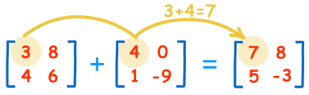

Yes, you can treat data frames and arrays like large lists where mathematical operations can be applied to individual elements or to entire columns or more!

### 2.4.1 Mathematical operations are applied differently depending on data type

- **numeric data**: operations applied as expected
- **non-numeric** (ie characters): error will be thrown
- **factors**: warning message and NAs returned
- **logical data** (`TRUE`/`FALSE`): coercion to numeric before applying operations

Therefore be careful to specify your numeric data for mathematical operations.

```r
mixed.df
```

```
##     Canadiana values manmade   type
## a      Canada      0    TRUE Nature
## b Maple Syrup      1   FALSE Nature
## c      Hockey      2    TRUE  Sport
```

```r
# Add to each element
mixed.df$values + 3
```

```
## [1] 3 4 5
```

```r
# Add columns to each other
mixed.df$values + mixed.df$values
```

```
## [1] 0 2 4
```

```r
# multiply each element by a constant
mixed.df$values * 4
```

```
## [1] 0 4 8
```

```r
# implicit coercion of logical to integer
mixed.df$manmade * 5
```

```
## [1] 5 0 5
```

```r
# Perform math on a factor
mixed.df$type * 6
```

```
## [1] NA NA NA
```

```r
# Convert the factor to a numeric first
as.numeric(mixed.df$type) * 7
```

```
## [1] 14 14  7
```

```r
# Can we perform math on non-numeric variables?
mixed.df$Canadiana + 8
```

```
## Error in mixed.df$Canadiana + 8: non-numeric argument to binary operator
```

## 2.5.0 Using the `apply()` family of functions to perform actions across data structures

The above are illustrative examples to see how our different data structures behave. In reality, you will want to do calculations across rows and columns, and not on your entire matrix or data frame.

### 2.5.1 The `apply()` function will recognize basic functions and use them on vectorized data

For example, we might have a count table where rows are genes, columns are samples, and we want to know the sum of all the counts for a gene. To do this, we can use the `apply()` function. `apply()` Takes an array, matrix (or something that can be coerced as such, like a numeric data frame), and applies a function over rows or columns. The `apply()` function takes the following parameters:

- `X`: an array. matrix or something that can be coerced to these objects
- `MARGIN`: defines how to apply the function; `1` = rows, `2` = columns.
- `FUN`: the function to be applied. Supplied as a function name *without* the `()` suffix
- `...`: this notation means we can pass additional parameters to our function defined by `FUN`.

and returns a vector, array or list depending on the nature of X.

Let’s practice by invoking the `sum` function.

```r
# Make a sample data frame of numeric values only
numeric.df = data.frame(geneA = numeric.vector, geneB = numeric.vector*2, geneC = numeric.vector*3)

# We now have a 12x3 dataframe
numeric.df
```

```
##    geneA geneB geneC
## 1     -1    -2    -3
## 2      0     0     0
## 3      1     2     3
## 4      2     4     6
## 5      3     6     9
## 6      4     8    12
## 7      5    10    15
## 8      6    12    18
## 9      7    14    21
## 10     8    16    24
## 11     9    18    27
## 12    10    20    30
```

```r
# Apply sum() to each row
apply(numeric.df, MARGIN = 1, sum)
```

```
##  [1] -6  0  6 12 18 24 30 36 42 48 54 60
```

```r
# Apply sum() to each column
apply(numeric.df, 2, sum)
```

```
## geneA geneB geneC
##    54   108   162
```

### 2.5.2 The other members of the `apply()` family

There are 3 additional members of the `apply()` family that perform similar functions with varying outputs

1. `lapply(data, FUN, ...)` is usable on dataframes, lists, and vectors. It returns a `list` as output.
- It will coerce non-list objects to a list
- Additional arguments to `FUN` will be applied from the `...`
2. `sapply(data, FUN, ...)` works similarly to `lapply()` except it tries to *simplify* the output to the most elementary data structure possible. i.e. it will return the simplest form of the data that makes sense as a representation.
3. `mapply(FUN, data, ...)` is short for “multivariate” apply and it applies a function to multiple lists or multiple vector arguments.

```r
# Use lapply on the columns of numeric.df
lapply(numeric.df, sum)
```

```
## $geneA
## [1] 54
##
## $geneB
## [1] 108
##
## $geneC
## [1] 162
```

```r
str(lapply(numeric.df, sum))
```

```
## List of 3
##  $ geneA: int 54
##  $ geneB: num 108
##  $ geneC: num 162
```

```r
# Use sapply on the columns of numeric.df
sapply(numeric.df, sum)
```

```
## geneA geneB geneC
##    54   108   162
```

```r
# We are returned a named vector
str(sapply(numeric.df, sum))
```

```
##  Named num [1:3] 54 108 162
##  - attr(*, "names")= chr [1:3] "geneA" "geneB" "geneC"
```

```r
# Using lapply and sapply and sum on an actual list
sum.list <- list(numeric.vector, numeric.df)
str(sum.list)
```

```
## List of 2
##  $ : int [1:12] -1 0 1 2 3 4 5 6 7 8 ...
##  $ :'data.frame':    12 obs. of  3 variables:
##   ..$ geneA: int [1:12] -1 0 1 2 3 4 5 6 7 8 ...
##   ..$ geneB: num [1:12] -2 0 2 4 6 8 10 12 14 16 ...
##   ..$ geneC: num [1:12] -3 0 3 6 9 12 15 18 21 24 ...
```

```r
# lapply on the list returns a list
lapply(sum.list, sum)
```

```
## [[1]]
## [1] 54
##
## [[2]]
## [1] 324
```

```r
# sapply on the list returns a vector
sapply(sum.list, sum)
```

```
## [1]  54 324
```

```r
# Use lapply to select portions from a list
sum.list <- list(numeric.df, numeric.df)

# Extract the first row from each member of the list
print("sum.list first rows:")
```

```
## [1] "sum.list first rows:"
```

```r
lapply(sum.list, "[", 1,)
```

```
## [[1]]
##   geneA geneB geneC
## 1    -1    -2    -3
##
## [[2]]
##   geneA geneB geneC
## 1    -1    -2    -3
```

```r
# Take a close look at what sapply returns in this case
sapply(sum.list, "[", 1,)
```

```
##       [,1] [,2]
## geneA -1   -1
## geneB -2   -2
## geneC -3   -3
```

```r
# Extract the 2nd column from each member of the list
print("sum.list second columns:")
```

```
## [1] "sum.list second columns:"
```

```r
lapply(sum.list, "[", , 2)
```

```
## [[1]]
##  [1] -2  0  2  4  6  8 10 12 14 16 18 20
##
## [[2]]
##  [1] -2  0  2  4  6  8 10 12 14 16 18 20
```

```r
# Take a close look at what sapply returns in this case
sapply(sum.list, "[", , 2)
```

```
##       [,1] [,2]
##  [1,]   -2   -2
##  [2,]    0    0
##  [3,]    2    2
##  [4,]    4    4
##  [5,]    6    6
##  [6,]    8    8
##  [7,]   10   10
##  [8,]   12   12
##  [9,]   14   14
## [10,]   16   16
## [11,]   18   18
## [12,]   20   20
```

Notice how in using `sapply()` to extract from a list of data frames, a single matrix was returned - a single output in the simplest form that maintains structure.

Now let’s give `mapply()` a try.

```r
# Use mapply in an example on numeric.vector
mapply(sum, numeric.vector, numeric.vector[0:3])
```

```
##  [1] -2  0  2  1  3  5  4  6  8  7  9 11
```

```r
mapply(sum, numeric.vector, numeric.vector)
```

```
##  [1] -2  0  2  4  6  8 10 12 14 16 18 20
```

```r
numeric.vector + numeric.vector
```

```
##  [1] -2  0  2  4  6  8 10 12 14 16 18 20
```

```r
# Use mapply in an example on numeric.df
mapply(sum, numeric.df, numeric.df)
```

```
## geneA geneB geneC
##   108   216   324
```

```r
mapply(sum, numeric.df)
```

```
## geneA geneB geneC
##    54   108   162
```

```r
# Use mapply on the rep function to see its output
mapply(rep, c("repeat", "this", "phrase"), 4)
```

```
##      repeat   this   phrase
## [1,] "repeat" "this" "phrase"
## [2,] "repeat" "this" "phrase"
## [3,] "repeat" "this" "phrase"
## [4,] "repeat" "this" "phrase"
```

So from our observations, we see what `mapply()` looks like

1. For our vectors, it has summed them element-wise. This is equivalent to `numeric.vector + numeric.vector`
2. For our dataframes, it has calculated the column-wise sums and matched them with columns of the same position in the other data frames to calculate a total sum.

In each case, it is applying `sum` to the first elements (or columns) of each argument, then the second elements, and so on. So new sets are formed for each element-wise position before applying the `FUN` argument!

[figure not shown]

## 2.6.0 Special data: `NA` and `NaN` values

Missing values in R are handled as `NA` (Not Available). Impossible values (like the results of dividing by zero) are represented by `NaN` (Not a Number). These types of values can be considered *null values*. These two types of values, especially NAs, have special ways to be dealt with, otherwise it may lead to errors in some functions.

For our purposes, we are not interested in keeping `NA` data within our datasets so we will usually detect and remove them or replace them within our data after it is imported.

### 2.6.1 Helpful functions and information for dealing with `NA` data

1. `is.na()` returns a logical vector reporting which values from your query are `NA`.
2. `complete.cases()` returns row-matched logical vector with a value of `TRUE` for rows **without** any `NA` values.
3. Some functions can ignore `NA` values with the `na.rm = TRUE` parameter: ie `mean()`, `sum()` etc.
4. Additional functions in the `tidyr` package can also be used to work with `NA` values.

```r
# Add some NAs to our data frame
mixed.df <- data.frame(Canadiana = character.vector,
                      values = c(3, NA, 9),
                      manmade = logical.vector[1:3],
                      type = c("Nature", "Nature", "Sport"),
                      unit = c(NA, "gallons", "Stanley Cups")
                      )
# Look at our updated data frame
mixed.df
```

```
##     Canadiana values manmade   type         unit
## a      Canada      3    TRUE Nature         <NA>
## b Maple Syrup     NA   FALSE Nature      gallons
## c      Hockey      9    TRUE  Sport Stanley Cups
```

```r
# Which entries are NA?
is.na(mixed.df)
```

```
##   Canadiana values manmade  type  unit
## a     FALSE  FALSE   FALSE FALSE  TRUE
## b     FALSE   TRUE   FALSE FALSE FALSE
## c     FALSE  FALSE   FALSE FALSE FALSE
```

```r
# Which rows are incomplete?
complete.cases(mixed.df)
```

```
## [1] FALSE FALSE  TRUE
```

```r
# Use some math functions
sum(mixed.df$values, na.rm = TRUE)
```

```
## [1] 12
```

# 3.0.0 Welcome to the `tidyverse`

Let’s begin with some definitions:

- **Variable**: A part of an experiment that can be controlled, changed, or measured.
- **Observation**: The results of measuring the variables of interest in an experiment.
- **Wide-format data**: variables may be listed in the first column, each forming a row of its own. Observations may be presented as columns that fill observed values for each variable.
- **Long-format data**: each variable is its own column, and the results of each measured variable are recorded in rows.

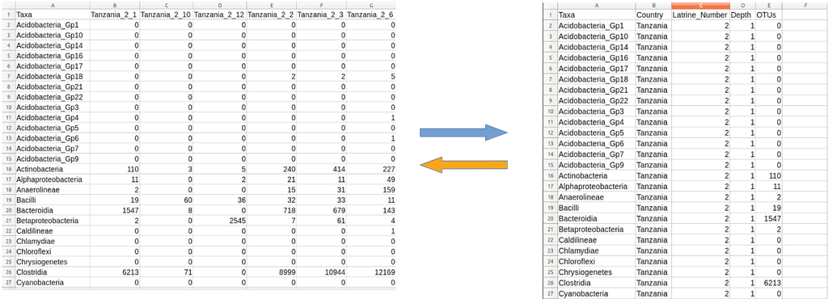

In data science, long format is preferred over wide format because it allows for an easier and more efficient subsetting and manipulation of the data. To read more about wide and long formats, visit [here](https://eagereyes.org/basics/spreadsheet-thinking-vs-database-thinking).

**Why tidy data?**

Data cleaning/wrangling (or dealing with ‘messy’ data) accounts for a huge chunk of a data scientist’s time. Ultimately, we want to get our data into a ‘tidy’ format (long format) where it is easy to manipulate, model and visualize. Having a consistent data structure and tools that work with that standardized data structure can help this process along.

**In Tidy data**:

1. Each variable forms a column.
2. Each observation forms a row.
3. Every cell is a *single* value.

This seems pretty straightforward, and it is. It is the datasets you get that will not be straightforward. Having a map of where to take your data is helpful to unraveling its structure and getting it into a usable format.

### 3.0.1 The 5 most common problems with messy datasets are:

- common headers are values, not variable names
- multiple variables are stored in one column
- variables are stored in both rows and columns
- a single variable stored in multiple tables
- multiple types of observational units are stored in the same table

**Observational units:** Of the three rules, the idea of observational units might be the hardest to grasp. As an example, you may be tracking a puppy population across 4 variables: age, height, weight, fur colour. Each observation unit is a puppy. However, you might be tracking *the same puppies* across multiple measurements - so a time factor applies. In that case, the observation unit now becomes puppy-time. Now each puppy-time measurement belongs in a different table (at least by tidy data standards). This, however, is a simple example and things can get more complex when taking into consideration what defines an observational unit. Check out [this blog post by Claus O. Wilke](https://clauswilke.com/blog/2014/07/21/keep-your-data-tidy-part-ii/) for a little more explanation.

Let’s begin this journey with data import.

## 3.1.0 Opening and saving files with the `readr` package - “All roads lead to Rome..”

*… but not all roads are easy to travel.*

Depending on format, data files can be opened in a number of ways. The simplest methods we will use involve the `readr` package as part of the `tidyverse`. These functions have already been developed to simplify the import process for users. The functions we will use most often are:

- Read in a delimited file: `read_delim()`, `read_csv()`, `read_tsv()`, `read_csv2()` [European datasets]
- Read in from a file, line by line: `read_lines()`

Let’s read in our first dataset so that we can convert from wide to long format.

```r
# Import the respiratory surveillance data
respData.df <- read_csv("data/2022-24_surveillanceDataset.csv")
# What is the basic shape of our data?
str(respData.df)
```

```
## spc_tbl_ [3,715 x 29] (S3: spec_tbl_df/tbl_df/tbl/data.frame)
##  $ Season              : chr [1:3715] "2023-2024" "2023-2024" "2023-2024" "2023-2024" ...
##  $ Year                : num [1:3715] 2024 2024 2024 2024 2024 ...
##  $ Week                : num [1:3715] 23 23 23 23 23 23 23 23 23 23 ...
##  $ Surveillance week   : num [1:3715] 40 40 40 40 40 40 40 40 40 40 ...
##  $ Reporting Laboratory: chr [1:3715] "Newfoundland" "Prince Edward Island" "Nova Scotia" "New Brunswick" ...
##  $ SARS-CoV-2 Tested   : chr [1:3715] "25911" "8528" "56416" "42456" ...
##  $ SARS-CoV-2 Positive : chr [1:3715] "3589" "846" "9244" "4186" ...
##  $ Flu Tested          : chr [1:3715] "19630" "5734" "42399" "40274" ...
##  $ A(H1)pdm09 Positive : chr [1:3715] "0" "0" "0" "925" ...
##  $ A(H3) Positive      : chr [1:3715] "0" "0" "0" "29" ...
##  $ A(UnS) Positive     : chr [1:3715] "1363" "542" "2925" "1907" ...
##  $ Total Flu A Positive: chr [1:3715] "1363" "542" "2925" "2861" ...
##  $ Total Flu B Positive: chr [1:3715] "187" "239" "690" "1058" ...
##  $ RSV Tested          : chr [1:3715] "19630" "5734" "34977" "39870" ...
##  $ RSV Positive        : chr [1:3715] "1063" "376" "1495" "1934" ...
##  $ HPIV Tested         : chr [1:3715] "19630" "674" "1392" "3839" ...
##  $ HPIV 1 Positive     : chr [1:3715] "31" "4" "16" "11" ...
##  $ HPIV 2 Positive     : chr [1:3715] "95" "1" "3" "8" ...
##  $ HPIV 3 Positive     : chr [1:3715] "432" "43" "22" "136" ...
##  $ HPIV 4 Positive     : chr [1:3715] "116" "9" "10" "35" ...
##  $ Other HPIV Positive : chr [1:3715] "0" "0" "0" "0" ...
##  $ ADV Tested          : chr [1:3715] "19630" "673" "1392" "3839" ...
##  $ ADV Positive        : chr [1:3715] "324" "44" "47" "135" ...
##  $ HMPV Tested         : chr [1:3715] "19630" "663" "1385" "3839" ...
##  $ HMPV Positive       : chr [1:3715] "529" "30" "21" "120" ...
##  $ EV/RV Tested        : chr [1:3715] "19630" "674" "1392" "3839" ...
##  $ EV/RV Positive      : chr [1:3715] "1844" "188" "257" "763" ...
##  $ HCoV Tested         : chr [1:3715] "19630" "658" "1391" "3839" ...
##  $ HCoV Positive       : chr [1:3715] "574" "35" "34" "153" ...
##  - attr(*, "spec")=
##   .. cols(
##   ..   Season = col_character(),
##   ..   Year = col_double(),
##   ..   Week = col_double(),
##   ..   `Surveillance week` = col_double(),
##   ..   `Reporting Laboratory` = col_character(),
##   ..   `SARS-CoV-2 Tested` = col_character(),
##   ..   `SARS-CoV-2 Positive` = col_character(),
##   ..   `Flu Tested` = col_character(),
```

[output cut: 8 more lines]

```
##   ..   `HPIV 1 Positive` = col_character(),
##   ..   `HPIV 2 Positive` = col_character(),
##   ..   `HPIV 3 Positive` = col_character(),
##   ..   `HPIV 4 Positive` = col_character(),
##   ..   `Other HPIV Positive` = col_character(),
##   ..   `ADV Tested` = col_character(),
##   ..   `ADV Positive` = col_character(),
##   ..   `HMPV Tested` = col_character(),
##   ..   `HMPV Positive` = col_character(),
##   ..   `EV/RV Tested` = col_character(),
##   ..   `EV/RV Positive` = col_character(),
##   ..   `HCoV Tested` = col_character(),
##   ..   `HCoV Positive` = col_character()
##   .. )
##  - attr(*, "problems")=<externalptr>
```

```r
# What does it look like
head(respData.df)
```

```
## # A tibble: 6 x 29
##   Season     Year  Week `Surveillance week` `Reporting Laboratory`
##   <chr>     <dbl> <dbl>               <dbl> <chr>
## 1 2023-2024  2024    23                  40 Newfoundland
## 2 2023-2024  2024    23                  40 Prince Edward Island
## 3 2023-2024  2024    23                  40 Nova Scotia
## 4 2023-2024  2024    23                  40 New Brunswick
## 5 2023-2024  2024    23                  40 Atlantic
## 6 2023-2024  2024    23                  40 Région Nord-Est
## # i 24 more variables: `SARS-CoV-2 Tested` <chr>, `SARS-CoV-2 Positive` <chr>,
## #   `Flu Tested` <chr>, `A(H1)pdm09 Positive` <chr>, `A(H3) Positive` <chr>,
## #   `A(UnS) Positive` <chr>, `Total Flu A Positive` <chr>,
## #   `Total Flu B Positive` <chr>, `RSV Tested` <chr>, `RSV Positive` <chr>,
## #   `HPIV Tested` <chr>, `HPIV 1 Positive` <chr>, `HPIV 2 Positive` <chr>,
## #   `HPIV 3 Positive` <chr>, `HPIV 4 Positive` <chr>,
## #   `Other HPIV Positive` <chr>, `ADV Tested` <chr>, `ADV Positive` <chr>, ...
```

### 3.1.1 The respiratory surveillance data covers multiple viruses

We can see that the respiratory surveillance dataset is 3715 entries across 29 columns. Looking closely at the columns we can see that they are a mix of virus types that come in sets of “Tested” vs “Positive” results. In some cases, there may be multiple variants that are being tested for a single virus type. Case in point, “Flu Tested” is accompanied by “A(H1)pdm09 Positive”, “A(H3) Positive”, “A(UnS) Positive”, “Total Flu A Positive” and “Total Flu B Positive”.

Here’s a quick table of the kinds of viruses and their coding as we’ll see it in our current dataframe.

| Table column code | Virus |
| --- | --- |
| ADV | Adenovirus |
| EV/RV | Enterovirus/Rhinovirus |
| Flu | Influenza |
| HCoV | Human Coronavirus |
| HPIV | Human Parainfluenza viruses |
| HPMV | Human Metapneumoviruses |
| RSV | Respiratory syncitial virus |
| SARS-CoV-2 | SARS Coronavirus 2 |

We also see that the data begins with some metadata variables: “Season”, “Year”, “Week”, “Surveillance week”, and “Reporting Laboratory”. Let’s begin some exploration of our data by gathering the unique values in those five metadata variables.

```r
# Look at the various values in our first 3 variables

cat("Season values: ")
```

```
## Season values:
```

```r
respData.df$Season %>% unique()
```

```
## [1] "2023-2024" "2022-2023"
```

```r
cat("\nYear values: ")
```

```
##
## Year values:
```

```r
respData.df$Year %>% unique()
```

```
## [1] 2024 2023 2022
```

```r
cat("\nUnique Weeks: ")
```

```
##
## Unique Weeks:
```

```r
respData.df$Week %>% unique()
```

```
##  [1] 23 22 21 20 19 18 17 16 15 14 13 12 11 10  9  8  7  6  5  4  3  2  1 52 50
## [26] 49 48 47 46 45 44 43 42 41 40 39 38 37 36 35 34 33 32 31 30 29 28 27 26 25
## [51] 24
```

```r
cat("\nUnique Surveillance Weeks: ")
```

```
##
## Unique Surveillance Weeks:
```

```r
respData.df$`Surveillance week` %>% unique()
```

```
##  [1] 40 39 38 37 36 35 34 33 32 31 30 29 28 27 26 25 24 23 22 21 20 19 18 17 15
## [26] 14 13 12 11 10  9  8  7  6  5  4  3  2  1  0 51 50 49 48 47 46 45 44 43 42
## [51] 41
```

```r
cat("\nUnique Reporting laboratories: ")
```

```
##
## Unique Reporting laboratories:
```

```r
respData.df$`Reporting Laboratory` %>% unique()
```

```
##  [1] "Newfoundland"                 "Prince Edward Island"
##  [3] "Nova Scotia"                  "New Brunswick"
##  [5] "Atlantic"                     "Région Nord-Est"
##  [7] "Québec-Chaudière-Appalaches"  "Centre-du-Québec"
##  [9] "Montréal-Laval"               "Ouest du Québec"
## [11] "Montérégie"                   "Province of Québec"
## [13] "P.H.O.L. - Ottawa"            "EORLA"
## [15] "P.H.O.L. - Kingston"          "UHN / Mount Sinai Hospital"
## [17] "P.H.O.L. - Toronto"           "Sick Kids Hospital - Toronto"
## [19] "Shared Hospital Laboratory"   "P.H.O.L. - Sault Ste. Marie"
## [21] "P.H.O.L. - Timmins"           "St. Joseph's - London"
## [23] "P.H.O.L. - London"            "P.H.O.L. - Orillia"
## [25] "P.H.O.L. - Thunder Bay"       "P.H.O.L. - Sudbury"
## [27] "P.H.O.L. - Hamilton"          "P.H.O.L. - Peterborough"
## [29] "St. Joseph's - Hamilton"      "Sault Area Hospital"
## [31] "Province of Ontario"          "Manitoba"
## [33] "Saskatchewan"                 "Alberta"
## [35] "Prairies"                     "British Columbia"
## [37] "Yukon"                        "Northwest Territories"
## [39] "Nunavut"                      "Territories"
## [41] "CANADA"                       "Canada"
## [43] "Montréal-Laval "              "P.H.O.L. - Toronto "
## [45] "St. Joseph's - London "       "Montréal-Laval  "
## [47] "P.H.O.L. - Toronto  "         "St. Joseph's - London  "
## [49] "Province of Québec "          "Province of Manitoba"
## [51] "Province of Saskatchewan"     "Province of Alberta"
```

```r
# What are the column names of our dataset?
cat("\ncolumn names: \n")
```

```
##
## column names:
```

```r
colnames(respData.df)
```

```
##  [1] "Season"               "Year"                 "Week"
##  [4] "Surveillance week"    "Reporting Laboratory" "SARS-CoV-2 Tested"
##  [7] "SARS-CoV-2 Positive"  "Flu Tested"           "A(H1)pdm09 Positive"
## [10] "A(H3) Positive"       "A(UnS) Positive"      "Total Flu A Positive"
## [13] "Total Flu B Positive" "RSV Tested"           "RSV Positive"
## [16] "HPIV Tested"          "HPIV 1 Positive"      "HPIV 2 Positive"
## [19] "HPIV 3 Positive"      "HPIV 4 Positive"      "Other HPIV Positive"
## [22] "ADV Tested"           "ADV Positive"         "HMPV Tested"
## [25] "HMPV Positive"        "EV/RV Tested"         "EV/RV Positive"
## [28] "HCoV Tested"          "HCoV Positive"
```

### 3.1.2 The respiratory surveillance data covers 2 seasons of data gathered across Canada

We can see from the above exploration that our data covers 2 sets of seasons: 2022-2023 and 2023-2024. The week data covers a total of 51 unique weeks, which is pretty much in line with how many weeks we see in the year (52).

If we were to dive into the data a little closer, we’d see that the “Week” and “Surveillance week” don’t necessarily match up. Rather, the data for each season, begins at week 35 (year-wise) but the surveillance week would be 0. This will be handy to understand later when we try to visualize our data.

Of the reporting laboratories, it appears that some are specifically totals for each province while others appear to be provincial testing laboratories. It’s a little messy but we’ll figure out how to clean that up when the time comes.

### 3.1.3 Use coercion to help identify invalid values

Let’s take one more cursory look at the data itself. If we were to revisit the output from `str()` we would see that the data in our remaining columns has been classified as “character” data. What values are these columns housing?

We can use coercion to help us investigate our assumptions about the data. From our cursory investigations of the table, the data looks very much like it should be numeric in nature. If we explicitly cast these values to a numeric datatype, R will create `NA` values from the entries that do not appear numeric. We can use this conversion to track down the location of the non-numeric values and identify what they are.

From there we can use a combination of `is.na()` and `which()` to track down the offending values.

```r
# Investigate the values in the virus testing data columns

respData.df %>%
  pull(6) %>%             # Pull out just the first data column
  as.numeric() %>%        # Convert to numeric. Any non-numeric values will become NA
  is.na() %>%             # Identify which values are NA
  which() %>%             # Pull down their locations
  respData.df[., 6] %>%   # Retrieve the non-numeric data from the table
  unlist() %>%            # Convert it to a simple vector for looking at
  unique()
```

```
## [1] "N.R." "N.R"  "N.C."
```

From our quick investigation, we can see that our non-numeric data consists of either “N.R”, “N.R.” or “N.C.” values. These are placeholders in the dataset where values were either “not recorded” or “not collected” for that period. We will have to deal with that information sooner or later.

## 3.2.0 The `tidyverse` package and it’s contents make manipulating data easier

While the tidyverse is composed of multiple packages, we will be focused on working with a subset of these: `dplyr`, `tidyr`, and `stringr`.

### 3.2.0.1 Redirect your output with `%>%` whenever you can!

To save on making extra variables in memory and to help make our code more concise, we should use of the `%>%` symbol. This is a redirection or pipe symbol similar to the `|` in Unix operating systems and is used for redirecting output from one function to the input of another. By thoughtfully combining this with other commands, we can alter or query our datasets with ease.

Whenever we are redirecting, we are implicitly passing our output to the first parameter of the next function. We may not always want to use the entirety of the output or we may want to also reuse that redirected output as part of another parameter. To do so we can use `.` to explicitly denote the redirected output.

**Native Piping in R:** Note that as of R vs 4.1.0 a native pipe symbol `|>` was added to the language which has the same function as the `%>%` symbol we are using. However, RStudio holds a shortcut set of keys `ctrl + shift + m` which can make it more convenient to insert while coding.

### 3.2.0.2 `dplyr` has functions for accessing and altering your data

We will use the “verbs” of the `dplyr` function often to massage the look of our data by changing column names or subsetting it. The most common verbs you will see in this course are.

| Function(s) | Description |
| --- | --- |
| `arrange()` | Arranging rows by column values |
| `count()`, `tally()` | Counting observations by group |
| `distinct()` | Subsetting rows by distinct or unique values |
| `filter()` | Subsetting rows by column values |
| `mutate()`, `transmute()` | Create, modify, or delete columns |
| `select()` | Subset columns using their names and types |
| `summarize()` or `summarise()` | Summarize by groups to fewer rows |
| `group_by()` vs. `ungroup()` | group by one or more variables |
| `rowwise()` | group data as single rows for calculations across each |
| `rename()`, and `relocate()` | Rename or move columns |

### 3.2.0.3 `tidyr` has additional functions for reshaping our data

The `tidyr` package will be most useful when we are trying to reshape our data from the wide to the long format or *vice versa*. This is much more useful for when we want to drastically alter portions or all of our data.

| Function(s) | Description |
| --- | --- |
| `pivot_longer()` | Pivot data from wide to long |
| `pivot_wider()` | Pivot data from long to wide |
| `extract()` | Extract a character column into multiple groups |
| `separate()` | Separate a character column into multiple groups |
| `unite()` | Unite multiple columns into one by pasting strings |
| `drop_na()` | Drop rows containing missing values |
| `replace_na()` | Replace NAs with specific values |

### 3.2.0.4 `stringr` provides functionality for searching data based on regular expressions

The `stringr` package will come in most useful when we are trying to fix string issues with our data. Many time our headers or data will contain spaces or poor formatting. Many times we will prefer to have our headers in lower case format, with any spaces replaced by an `_`. We’ll also use verbs from this package to make any variables or data more concise.

| Category | Function(s) | Description |
| --- | --- | --- |
| **String analysis** | `str_count()` | Count the number of matches in a string |
| **String retrieval** | `str_detect()` | Detect the presence (or absence) of a pattern in string |
|  | `str_extract()` and `str_extract_all()` | Extract matching patterns from a string |
|  | `str_match()` and `str_match_all()` | Extract matched groups from a string |
|  | `str_subset()` and `str_which()` | Keep or find strings matching a pattern |
| **String alteration** | `str_remove()` and `str_remove_all()` | Remove matched patterns from a string |
|  | `str_split()`, `str_split_fixed()`, and `str_split_n()` | Split a string into pieces |
|  | `str_c()` | Concatenate multiple strings into a single string with optional separator |
|  | `str_flatten()` | Flatten a string |
|  | `str_sub()` | Extract and replace substrings from a character vector |
|  | `str_to_upper()` and `str_to_lower()` | Convert case of a string |

[figure not shown]

Time to tackle our dataset!

### 3.2.2 Use `mutate_at()` and `mutate()` to create new variables

We have two sets of viruses where multiple strains are being tested:

- Influenza is being tracked across multiple versions of influenza A and a single influenza B total. A close look at the data suggests we can simply combine the `Total Flu A Positive` and `Total Flu B Positive` variables.
- Human parainfluenza viruses (HPIV) are being track across 5 categories, which we must consolidate together.

In each case, we’ll create an appropriately-matched variable name that will help us down the line by matching with the “Tested” version of virus. To accomplish this we’ll use the `mutate()` verb.

*Before that* we’ll take a moment to try and type-convert all the measurement columns to numeric values. Much like we saw in **section 3.1.3**, non-numeric values will be converted to `NA` values in the process. We can mutate across multiple columns using the `mutate_at()` verb which will take 2 parameters:

- `.vars`: a tidy-select definition of the variable names (aka column names) we want to use. This can be chosen in a directly and indirectly by using names or positions.
- `.funs`: the *name* of the function we wish to apply to each column we’ve chosen. In this case it’s going to be the `as.numeric` function.

For this and following sections, We’ll be using a series of `%>%` so for now we won’t save our work to a new object. When we’ve implemented the whole set of changes, we’ll save a final version.

```r
# Start by pivoting the data using the first 5 columns as a unique identifier

respData.df %>%
  # Convert the measurements to numeric
  mutate_at(.vars = -c(1:5), .funs = as.numeric) %>%

  # Create some new "total positive" columns
  mutate(`Flu Positive` = `Total Flu A Positive`+`Total Flu B Positive`,
         "HPIV Positive" = `HPIV 1 Positive` + `HPIV 2 Positive` + `HPIV 3 Positive` + `HPIV 4 Positive` + `Other HPIV Positive`
         )
```

```
## # A tibble: 3,715 x 31
##    Season     Year  Week `Surveillance week` `Reporting Laboratory`
##    <chr>     <dbl> <dbl>               <dbl> <chr>
##  1 2023-2024  2024    23                  40 Newfoundland
##  2 2023-2024  2024    23                  40 Prince Edward Island
##  3 2023-2024  2024    23                  40 Nova Scotia
##  4 2023-2024  2024    23                  40 New Brunswick
##  5 2023-2024  2024    23                  40 Atlantic
##  6 2023-2024  2024    23                  40 Région Nord-Est
##  7 2023-2024  2024    23                  40 Québec-Chaudière-Appalaches
##  8 2023-2024  2024    23                  40 Centre-du-Québec
##  9 2023-2024  2024    23                  40 Montréal-Laval
## 10 2023-2024  2024    23                  40 Ouest du Québec
## # i 3,705 more rows
## # i 26 more variables: `SARS-CoV-2 Tested` <dbl>, `SARS-CoV-2 Positive` <dbl>,
## #   `Flu Tested` <dbl>, `A(H1)pdm09 Positive` <dbl>, `A(H3) Positive` <dbl>,
## #   `A(UnS) Positive` <dbl>, `Total Flu A Positive` <dbl>,
## #   `Total Flu B Positive` <dbl>, `RSV Tested` <dbl>, `RSV Positive` <dbl>,
## #   `HPIV Tested` <dbl>, `HPIV 1 Positive` <dbl>, `HPIV 2 Positive` <dbl>,
## #   `HPIV 3 Positive` <dbl>, `HPIV 4 Positive` <dbl>, ...
```

### 3.2.3 Reformat our wide table with `pivot_longer()`

Our next step in the process should be to try and consolidate all of our virus measurements (Tested and Positive) into a single pair of columns denoting the measurement type (ie “Flu Tested” or “Flu Positive”) and the measurement value. To save ourselves some downstream trouble, we’ll also take the time to eliminate some of the variables in our dataset that are now redundant. That includes:

1. All the “Flu XX Positive” columns except specifically the “Flu Positive” variable we created with `mutate()`. These are in positions 9-13 of our dataframe.
2. All the “HPIV X Positive” columns except specifically the “HPIV Positive” variable we created with `mutate()`. These are in position 17-21 of our datarame.

We’ll remove these offending columns with a quick call to `select()` before we pivot the data.

Next we will use the `pivot_longer()` function to convert our wide-format data over to long-format. For our purposes, we will rely on four parameters:

1. `data`: the data frame (and columns) that we wish to transform.
2. `cols`: the columns that we wish to gather/collapse into a long format.
3. `names_to`: the variable name of the *new* column to hold the collapsed information from our current columns.
4. `values_to`: The variable name of the values for each observation that we are collapsing down.

```r
# Start by pivoting the data using the first 5 columns as a unique identifier

respData.df %>%
  # Convert the measurements to numeric
  mutate_at(.vars = -c(1:5), .funs = as.numeric) %>%

  # Create some new "total positive" columns
  mutate(`Flu Positive` = `Total Flu A Positive`+`Total Flu B Positive`,
         "HPIV Positive" = `HPIV 1 Positive` + `HPIV 2 Positive` + `HPIV 3 Positive` + `HPIV 4 Positive` + `Other HPIV Positive`
         ) %>%

  # Drop some of the columns from our analysis
  select(-c(9:13, 17:21)) %>%

  # Pivot the data using the first 5 variables as a unique id
  pivot_longer(cols = -c(1:5), names_to = "category", values_to = "count")
```

```
## # A tibble: 59,440 x 7
##    Season   Year  Week `Surveillance week` `Reporting Laboratory` category count
##    <chr>   <dbl> <dbl>               <dbl> <chr>                  <chr>    <dbl>
##  1 2023-2~  2024    23                  40 Newfoundland           SARS-Co~ 25911
##  2 2023-2~  2024    23                  40 Newfoundland           SARS-Co~  3589
##  3 2023-2~  2024    23                  40 Newfoundland           Flu Tes~ 19630
##  4 2023-2~  2024    23                  40 Newfoundland           RSV Tes~ 19630
##  5 2023-2~  2024    23                  40 Newfoundland           RSV Pos~  1063
##  6 2023-2~  2024    23                  40 Newfoundland           HPIV Te~ 19630
##  7 2023-2~  2024    23                  40 Newfoundland           ADV Tes~ 19630
##  8 2023-2~  2024    23                  40 Newfoundland           ADV Pos~   324
##  9 2023-2~  2024    23                  40 Newfoundland           HMPV Te~ 19630
## 10 2023-2~  2024    23                  40 Newfoundland           HMPV Po~   529
## # i 59,430 more rows
```

### 3.2.4 Split character data variables using `separate_*`

Looking at our output from above, we now see that our data is in a mostly long format but not yet in a tidy format for our purposes. We’ve managed to collect all the testing AND result data into the same set of columns: `category` and `count`. Ideally want we want is to add two more variables to our data so that our final table looks more like:

| Season | Year | Week | Surveillance Week | Reporting Laboratory | Category | Tested | Positive | Percent Positive |
| --- | --- | --- | --- | --- | --- | --- | --- | --- |
| 2023-2024 | 2024 | 23 | 40 | Newfoundland | EV/RV | 19630 | 1844 | 0.0939 |
| … | … | … | … | … | … | … | … | … |

To accomplish this we’ll need to execute a few additional transformations. The next step will need us to break our category data into the “virus” and the “type” of value now. The secondary column will indicate if the data in that observation pertains to “Tested” vs “Positive” counts. To split these values apart from the “category” variable we can turn to a few similar verbs:

- `separate()`: now mostly deprecated, this simple verb allows you to separate character values into multiple sets (columns) using a text delimiter.

The above has been essentially replaced with more specific versions that have underlying code that relies on the `stringr` packages which is also part of the `tidyverse`.

- `separate_wider_delim()`: split data into new columns by a delimiter
- `separate_wider_position()`: split data into new columns based on fixed widths
- `separate_wider_regex()`: split data into new columns based on regular expressions, going beyond a single character delimiter.

Looking carefully at our `category` values, we could identify that each entry takes the form of `<virus> <measurement_type>` with a single space between each or it could be `<virus> Tested` vs `<virus> Positive`. We’ll go with the latter route and play with `separate_wider_regex()`.

With `separate_wider_regex()` we can actually provide multiple regular expressions as a named vector to define our column information. This should consolidate the regular expressions as though they were a single one. The named vector will take the form of `c(colName1 = "regExp1", colName2 = "regExp2", ..)`. If an entry in the vector has no name, then it will result in no column being created.

```r
# Start by pivoting the data using the first 5 columns as a unique identifier

respData.df %>%
  # Convert the measurements to numeric
  mutate_at(.vars = -c(1:5), .funs = as.numeric) %>%

  # Create some new "total positive" columns
  mutate(`Flu Positive` = `Total Flu A Positive`+`Total Flu B Positive`,
         "HPIV Positive" = `HPIV 1 Positive` + `HPIV 2 Positive` + `HPIV 3 Positive` + `HPIV 4 Positive` + `Other HPIV Positive`
         ) %>%

  # Drop some of the columns from our analysis
  select(-c(9:13, 17:21)) %>%

  # Pivot the data using the first 5 variables as a unique id
  pivot_longer(cols = -c(1:5), names_to = "category", values_to = "count") %>%

  # Separate out the "Tested" from the "Positive"
  separate_wider_regex(., cols = category, patterns = c(virus= ".*", " ", type="Tested|Positive"))
```

```
## # A tibble: 59,440 x 8
##    Season     Year  Week `Surveillance week` `Reporting Laboratory` virus  type
##    <chr>     <dbl> <dbl>               <dbl> <chr>                  <chr>  <chr>
##  1 2023-2024  2024    23                  40 Newfoundland           SARS-~ Test~
##  2 2023-2024  2024    23                  40 Newfoundland           SARS-~ Posi~
##  3 2023-2024  2024    23                  40 Newfoundland           Flu    Test~
##  4 2023-2024  2024    23                  40 Newfoundland           RSV    Test~
##  5 2023-2024  2024    23                  40 Newfoundland           RSV    Posi~
##  6 2023-2024  2024    23                  40 Newfoundland           HPIV   Test~
##  7 2023-2024  2024    23                  40 Newfoundland           ADV    Test~
##  8 2023-2024  2024    23                  40 Newfoundland           ADV    Posi~
##  9 2023-2024  2024    23                  40 Newfoundland           HMPV   Test~
## 10 2023-2024  2024    23                  40 Newfoundland           HMPV   Posi~
## # i 59,430 more rows
## # i 1 more variable: count <dbl>
```

### 3.2.5 Redistribute the “type” columns using `pivot_wider()`

We’ve successfully separated our virus category from our measurement type and now we have the `type` variable representing Tested vs Positive counts. What we need, however, is to keep working towards our example in **section 3.2.4** where we have *specific* variables for “Tested” and “Positive” counts.

In order to spread our data back out into multiple columns, we’ll use the `pivot_wider()` verb which minimally requires a couple of parameters to work:

- `names_from`: the column that will be used to sample values as the new column names of your table.
- `values_from`: the column that will be used to populate the new columns of your table.
- `id_cols`: while optional, this can be used to name the columns that uniquely identify each of your observations, dropping any unnamed variables. If none are listed, then **all remaining columns** will be used by default.

```r
# Start by pivoting the data using the first 5 columns as a unique identifier

respData.df %>%
  # Convert the measurements to numeric
  mutate_at(.vars = -c(1:5), .funs = as.numeric) %>%

  # Create some new "total positive" columns
  mutate(`Flu Positive` = `Total Flu A Positive`+`Total Flu B Positive`,
         "HPIV Positive" = `HPIV 1 Positive` + `HPIV 2 Positive` + `HPIV 3 Positive` + `HPIV 4 Positive` + `Other HPIV Positive`
         ) %>%

  # Drop some of the columns from our analysis
  select(-c(9:13, 17:21)) %>%

  # Pivot the data using the first 5 variables as a unique id
  pivot_longer(cols = -c(1:5), names_to = "category", values_to = "count") %>%

  # Separate out the "Tested" from the "Positive"
  separate_wider_regex(., cols = category, patterns = c(virus = ".*", " ", type = "Tested|Positive")) %>%

  # Bring out the type data into Tested vs Positive columns
  pivot_wider(names_from = type, values_from = count)
```

```
## # A tibble: 29,720 x 8
##    Season     Year  Week `Surveillance week` `Reporting Laboratory` virus Tested
##    <chr>     <dbl> <dbl>               <dbl> <chr>                  <chr>  <dbl>
##  1 2023-2024  2024    23                  40 Newfoundland           SARS~  25911
##  2 2023-2024  2024    23                  40 Newfoundland           Flu    19630
##  3 2023-2024  2024    23                  40 Newfoundland           RSV    19630
##  4 2023-2024  2024    23                  40 Newfoundland           HPIV   19630
##  5 2023-2024  2024    23                  40 Newfoundland           ADV    19630
##  6 2023-2024  2024    23                  40 Newfoundland           HMPV   19630
##  7 2023-2024  2024    23                  40 Newfoundland           EV/RV  19630
##  8 2023-2024  2024    23                  40 Newfoundland           HCoV   19630
##  9 2023-2024  2024    23                  40 Prince Edward Island   SARS~   8528
## 10 2023-2024  2024    23                  40 Prince Edward Island   Flu     5734
## # i 29,710 more rows
## # i 1 more variable: Positive <dbl>
```

### 3.2.6 Update/Fix some values with `mutate()` and regular expressions

Nearly there! We just have to fix up some values in our `Reporting Laboratory` variable and we’ll create a new variable called `Percent Positive` that uses the data from the newly created `Tested` and `Positive` variables.

In the case of `Reporting Laboratory` we will want to remove “Province of” from some of the values and replace all the instances of “CANADA” with “Canada” for consistency. You can refer to the output in **section 3.1.1** if you’d like to see the values again.

To accomplish our changes, we’ll also use the `str_remove_all()` and `str_replace()` functions. In our case we could interchangeably use the `str_remove()` and `str_replace_all()` functions.

```r
# Start by pivoting the data using the first 5 columns as a unique identifier

respData.df %>%
  # Convert the measurements to numeric
  mutate_at(.vars = -c(1:5), .funs = as.numeric) %>%

  # Create some new "total positive" columns
  mutate(`Flu Positive` = `Total Flu A Positive`+`Total Flu B Positive`,
         "HPIV Positive" = `HPIV 1 Positive` + `HPIV 2 Positive` + `HPIV 3 Positive` + `HPIV 4 Positive` + `Other HPIV Positive`
         ) %>%

  # Drop some of the columns from our analysis
  select(-c(9:13, 17:21)) %>%

  # Pivot the data using the first 5 variables as a unique id
  pivot_longer(cols = -c(1:5), names_to = "category", values_to = "count") %>%

  # Separate out the "Tested" from the "Positive"
  separate_wider_regex(., cols = category, patterns = c(virus = ".*", " ", type = "Tested|Positive")) %>%

  # Bring out the type data into Tested vs Positive columns
  pivot_wider(names_from = type, values_from = count) %>%

  # Clean up the Reporting Lab names a little bit to remove redundancy
  mutate(`Reporting Laboratory` = str_remove_all(string = `Reporting Laboratory`, pattern = "[Pp]rovince of "),
         `Reporting Laboratory` = str_replace(string = `Reporting Laboratory`, pattern = "CANADA", replacement = "Canada"),

         # Create a new variable to calculate % positive cases
         "Percent Positive" = Positive/Tested*100
         )
```

```
## # A tibble: 29,720 x 9
##    Season     Year  Week `Surveillance week` `Reporting Laboratory` virus Tested
##    <chr>     <dbl> <dbl>               <dbl> <chr>                  <chr>  <dbl>
##  1 2023-2024  2024    23                  40 Newfoundland           SARS~  25911
##  2 2023-2024  2024    23                  40 Newfoundland           Flu    19630
##  3 2023-2024  2024    23                  40 Newfoundland           RSV    19630
##  4 2023-2024  2024    23                  40 Newfoundland           HPIV   19630
##  5 2023-2024  2024    23                  40 Newfoundland           ADV    19630
##  6 2023-2024  2024    23                  40 Newfoundland           HMPV   19630
##  7 2023-2024  2024    23                  40 Newfoundland           EV/RV  19630
##  8 2023-2024  2024    23                  40 Newfoundland           HCoV   19630
##  9 2023-2024  2024    23                  40 Prince Edward Island   SARS~   8528
## 10 2023-2024  2024    23                  40 Prince Edward Island   Flu     5734
## # i 29,710 more rows
## # i 2 more variables: Positive <dbl>, `Percent Positive` <dbl>
```

### 3.2.7 Update your variable names with `rename()` for clarity and simplicity

To finish up our wrangling process we’ll take a moment to fix up our columns names. “Why should we?” you ask. By renaming the column names to something more consistent, we won’t have to keep using additional back-tick notation in our code.

To accomplish our changes we’ll make use of the `rename_with()` verb which can utilize a provided function in the `.fn` parameter. We’ll use some more `stringr` functions to help with that process. Namely `str_to_title` and `str_remove_all` again.

```r
# Start by pivoting the data using the first 5 columns as a unique identifier

respData.df %>%
  # Convert the measurements to numeric
  mutate_at(.vars = -c(1:5), .funs = as.numeric) %>%

  # Create some new "total positive" columns
  mutate(`Flu Positive` = `Total Flu A Positive`+`Total Flu B Positive`,
         "HPIV Positive" = `HPIV 1 Positive` + `HPIV 2 Positive` + `HPIV 3 Positive` + `HPIV 4 Positive` + `Other HPIV Positive`
         ) %>%

  # Drop some of the columns from our analysis
  select(-c(9:13, 17:21)) %>%

  # Pivot the data using the first 5 variables as a unique id
  pivot_longer(cols = -c(1:5), names_to = "category", values_to = "count") %>%

  # Separate out the "Tested" from the "Positive"
  separate_wider_regex(., cols = category, patterns = c(virus = ".*", " ", type = "Tested|Positive")) %>%

  # Bring out the type data into Tested vs Positive columns
  pivot_wider(names_from = type, values_from = count) %>%

  # Clean up the Reporting Lab names a little bit to remove redundancy
  mutate(`Reporting Laboratory` = str_remove_all(string = `Reporting Laboratory`, pattern = "[Pp]rovince of "),
         `Reporting Laboratory` = str_replace(string = `Reporting Laboratory`, pattern = "CANADA", replacement = "Canada"),
         "Percent Positive" = Positive/Tested*100
         ) %>%

  # Rename the variable names a bit to all begin with upper case
  rename_with(., .fn = str_to_title) %>%
  rename_with(., .fn = function(x) str_remove_all(string = x, pattern = "\\s"))
```

```
## # A tibble: 29,720 x 9
##    Season  Year  Week SurveillanceWeek ReportingLaboratory Virus Tested Positive
##    <chr>  <dbl> <dbl>            <dbl> <chr>               <chr>  <dbl>    <dbl>
##  1 2023-~  2024    23               40 Newfoundland        SARS~  25911     3589
##  2 2023-~  2024    23               40 Newfoundland        Flu    19630     1550
##  3 2023-~  2024    23               40 Newfoundland        RSV    19630     1063
##  4 2023-~  2024    23               40 Newfoundland        HPIV   19630      674
##  5 2023-~  2024    23               40 Newfoundland        ADV    19630      324
##  6 2023-~  2024    23               40 Newfoundland        HMPV   19630      529
##  7 2023-~  2024    23               40 Newfoundland        EV/RV  19630     1844
##  8 2023-~  2024    23               40 Newfoundland        HCoV   19630      574
##  9 2023-~  2024    23               40 Prince Edward Isla~ SARS~   8528      846
## 10 2023-~  2024    23               40 Prince Edward Isla~ Flu     5734      781
## # i 29,710 more rows
## # i 1 more variable: PercentPositive <dbl>
```